# phase_5

hello !!

Objective : Create a credit scoring Model that predicts the chance of a given loan applicant defaulting on loan repayment.

Dataset_Link : https://www.kaggle.com/ajay1735/hmeq-data

```python
import numpy as np
import pandas as pd
import matplotlib.pyplot as plt
import seaborn as sns
import os
import copy
from sklearn.preprocessing import LabelEncoder
from sklearn.model_selection import train_test_split
from sklearn.impute import SimpleImputer
pd.options.mode.chained_assignment = None
```

#### functions

```python
# EXPLORATION FUNCTIONS

def corr(X,Y):
    return np.corrcoef(X,Y)[0][1]

def perc_missing(X):
    return (len(X)-X.count())*100/len(X)


def file_size(file_path):
    if os.path.isfile(file_path):
        file_info = os.stat(file_path)
        num=file_info.st_size
        for x in ['bytes', 'KB', 'MB', 'GB', 'TB']:
            if num < 1024.0:
                return "%3.1f %s" % (num, x)
            num /= 1024.0


def class_dist(df,class_col):
    df_count=(df
              .groupby(class_col)
              .agg({class_col:'count'}))

    df_count=df_count.rename({class_col:'count'},axis=1)
    df_count['percent']=df_count['count']*100/df_count['count'].sum()
    df_count = df_count.reset_index()
    return df_count

def feature(df,cols):
    d=df[cols]
    return d

def missing(dataset,missing_col,target_col):
    feature_2=copy.deepcopy(dataset[[missing_col,target_col]])
    feature_2['is_null']=feature_2[missing_col].isna()

    f2_missing=feature_2.groupby('is_null').agg({target_col:'mean'}).reset_index()
    f2_missing=f2_missing.rename({target_col:'%default'},axis=1)
    f2_missing['count']=feature_2.groupby('is_null').agg({target_col:'count'})[target_col]
    f2_missing['no_default']=feature_2.groupby('is_null').agg({target_col:'sum'})[target_col]
    return f2_missing


def categorical_distribution(dataset,col,target_col):
    f5_bin=dataset.groupby(col).agg({target_col:'count'})
    f5_bin=f5_bin.rename({target_col:'count'},axis=1).reset_index()
    f5_bin['no_default']=np.array(dataset.groupby(col).agg({target_col:'sum'})[target_col])
    f5_bin['%default']=np.array(dataset.groupby(col).agg({target_col:'mean'})[target_col])
    return f5_bin

def continous_distribution(dataset,col,target_col,bin_nos):
    feature_9=copy.deepcopy(dataset[[col,target_col]])
    name=col+'_binned'
    feature_9[name]= pd.cut(x=feature_9[col],bins=bin_nos)

    clage_bins=feature_9.groupby(name).agg({target_col:'count'})
    clage_bins=clage_bins.rename({target_col:'count'},axis=1).reset_index()
    clage_bins['no_default']=np.array(feature_9.groupby(name).agg({target_col:'sum'})[target_col])
    clage_bins['%_default']=np.array(feature_9.groupby(name).agg({target_col:'mean'})[target_col])
    return clage_bins



def new_bins(dataset,col,target_col,arr):

    def bins(row):
        for i in arr:
            if row>=i[0] and row<=i[1]:
                return (i)

    feature_7=copy.deepcopy(dataset[[col,target_col]])
    feature_7['new_bins']=feature_7[col].apply(bins)


    derog_bins_new=feature_7.groupby('new_bins').agg({target_col:'count'})
    derog_bins_new=derog_bins_new.rename({target_col:'count'},axis=1).reset_index()
    derog_bins_new['no_default']=np.array(feature_7.groupby('new_bins').agg({target_col:'sum'})[target_col])
    derog_bins_new['%_default']=np.array(feature_7.groupby('new_bins').agg({target_col:'mean'})[target_col])
    return derog_bins_new

### TRANSFORMERS FUNCTIONS

def col_imputer(fit_dataset,transforms_datasets,col,value):
    obj = SimpleImputer(strategy='constant',fill_value=value)
    obj.fit(np.array(fit_dataset[col]).reshape(-1, 1))

    for i in transforms_datasets:
        i.loc[:,col]=obj.transform(np.array(i[col]).reshape(-1, 1))

def is_null_new_column(fit_dataset,transforms_datasets,col):
    name='is_null_'+col
    le = LabelEncoder()
    le.fit(fit_dataset[col].isna())

    for i in transforms_datasets:
        i.loc[:,name] = le.transform(i[col].isna())


def label_encoder(fit_dataset,transforms_datasets,col):
    le = LabelEncoder()
    le.fit(fit_dataset[col])

    for i in transforms_datasets:
        i.loc[:,col] = le.transform(i[col])

def one_hot_encoder(fit_dataset, transforms_datasets, col):
    enc = OneHotEncoder(handle_unknown='ignore')
    enc.fit(fit_dataset[[col]])
    categories=enc.categories_
    for i in transforms_datasets:
        temp=enc.transform(i[[col]]).toarray()
        indx=0
        for c in categories[0]:
            name=col+'_'+c
            i.loc[:,name]=temp[:,indx]
            indx+=1


def func_on_dataframe(datasets,cols_apply,result_cols,method):
    for ds in datasets:
        for cl in range(len(cols_apply)):
            ds.loc[:,result_cols[cl]]=ds[cols_apply[cl]].apply(method)
```

### Reading data

```python
# file_size
file_size('hmeq.csv')
```

```
'393.7 KB'
```

```python
df = pd.read_csv('hmeq.csv')
```

```python
df.head(10)
```

|  | BAD | LOAN | MORTDUE | VALUE | REASON | JOB | YOJ | DEROG | DELINQ | CLAGE | NINQ | CLNO | DEBTINC |
| --- | --- | --- | --- | --- | --- | --- | --- | --- | --- | --- | --- | --- | --- |
| 0 | 1 | 1100 | 25860.0 | 39025.0 | HomeImp | Other | 10.5 | 0.0 | 0.0 | 94.366667 | 1.0 | 9.0 | NaN |
| 1 | 1 | 1300 | 70053.0 | 68400.0 | HomeImp | Other | 7.0 | 0.0 | 2.0 | 121.833333 | 0.0 | 14.0 | NaN |
| 2 | 1 | 1500 | 13500.0 | 16700.0 | HomeImp | Other | 4.0 | 0.0 | 0.0 | 149.466667 | 1.0 | 10.0 | NaN |
| 3 | 1 | 1500 | NaN | NaN | NaN | NaN | NaN | NaN | NaN | NaN | NaN | NaN | NaN |
| 4 | 0 | 1700 | 97800.0 | 112000.0 | HomeImp | Office | 3.0 | 0.0 | 0.0 | 93.333333 | 0.0 | 14.0 | NaN |
| 5 | 1 | 1700 | 30548.0 | 40320.0 | HomeImp | Other | 9.0 | 0.0 | 0.0 | 101.466002 | 1.0 | 8.0 | 37.113614 |
| 6 | 1 | 1800 | 48649.0 | 57037.0 | HomeImp | Other | 5.0 | 3.0 | 2.0 | 77.100000 | 1.0 | 17.0 | NaN |
| 7 | 1 | 1800 | 28502.0 | 43034.0 | HomeImp | Other | 11.0 | 0.0 | 0.0 | 88.766030 | 0.0 | 8.0 | 36.884894 |
| 8 | 1 | 2000 | 32700.0 | 46740.0 | HomeImp | Other | 3.0 | 0.0 | 2.0 | 216.933333 | 1.0 | 12.0 | NaN |
| 9 | 1 | 2000 | NaN | 62250.0 | HomeImp | Sales | 16.0 | 0.0 | 0.0 | 115.800000 | 0.0 | 13.0 | NaN |

```python
df.shape
#5960 data points, 13 features
```

```
(5960, 13)
```

### DATASET description

BAD: 1 = client defaulted on loan 0 = loan repaid

LOAN: Amount of the loan request

MORTDUE: Amount due on existing mortgage

VALUE: Value of current property

REASON: DebtCon = debt consolidation HomeImp = home improvement

JOB: Six occupational categories

YOJ: Years at present job

DEROG: Number of major derogatory reports

DELINQ: Number of delinquent credit lines

CLAGE: Age of oldest trade line in months

NINQ: Number of recent credit lines

CLNO: Number of credit lines

DEBTINC: Debt-to-income ratio

### class distribution

```python
df_count=class_dist(df,'BAD') #class distribution of given dataset
df_count
```

|  | BAD | count | percent |
| --- | --- | --- | --- |
| 0 | 0 | 4771 | 80.050336 |
| 1 | 1 | 1189 | 19.949664 |

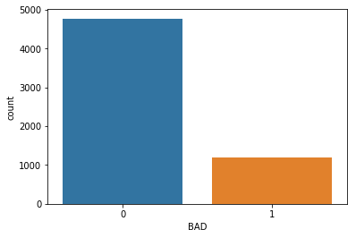

```python
sns.barplot(data=df_count,x='BAD',y='count')
```

### data frame

```python
df.dtypes.value_counts()
# types of features
# 2 categorical , 11 numerical
```

```
float64    9
object     2
int64      2
dtype: int64
```

```python
df.corr()['BAD'].sort_values() # correlation with class
```

```
CLAGE     -0.170499
LOAN      -0.075099
YOJ       -0.060238
MORTDUE   -0.048219
VALUE     -0.029954
CLNO      -0.004157
NINQ       0.174980
DEBTINC    0.199835
DEROG      0.276081
DELINQ     0.354107
BAD        1.000000
Name: BAD, dtype: float64
```

### missing values

```python
df_missing=df.count()
df_missing = pd.DataFrame(df_missing)
df_missing=df_missing.rename({0:'present/5960'},axis=1)
df_missing['percent_missing']=(5960 - df_missing['present/5960'])*100/5960
```

```python
df_missing # missing values in each feature
```

|  | present/5960 | percent_missing |
| --- | --- | --- |
| BAD | 5960 | 0.000000 |
| LOAN | 5960 | 0.000000 |
| MORTDUE | 5442 | 8.691275 |
| VALUE | 5848 | 1.879195 |
| REASON | 5708 | 4.228188 |
| JOB | 5681 | 4.681208 |
| YOJ | 5445 | 8.640940 |
| DEROG | 5252 | 11.879195 |
| DELINQ | 5380 | 9.731544 |
| CLAGE | 5652 | 5.167785 |
| NINQ | 5450 | 8.557047 |
| CLNO | 5738 | 3.724832 |
| DEBTINC | 4693 | 21.258389 |

```python
df['missing_features']=(df.isna().sum(axis = 1))
```

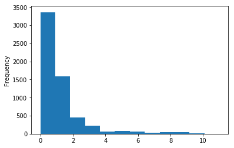

```python
df['missing_features'].plot.hist(bins=12)
```

```python
categorical_distribution(df,'missing_features','BAD') # missing values in datapoints
```

|  | missing_features | count | no_default | %default |
| --- | --- | --- | --- | --- |
| 0 | 0 | 3364 | 300 | 0.089180 |
| 1 | 1 | 1589 | 606 | 0.381372 |
| 2 | 2 | 449 | 180 | 0.400891 |
| 3 | 3 | 219 | 39 | 0.178082 |
| 4 | 4 | 64 | 6 | 0.093750 |
| 5 | 5 | 83 | 8 | 0.096386 |
| 6 | 6 | 66 | 22 | 0.333333 |
| 7 | 7 | 25 | 14 | 0.560000 |
| 8 | 8 | 39 | 7 | 0.179487 |
| 9 | 9 | 49 | 6 | 0.122449 |
| 10 | 10 | 11 | 0 | 0.000000 |
| 11 | 11 | 2 | 1 | 0.500000 |

```python
new_bins(df,'missing_features','BAD',[(0,0),(1,1),(2,2),(3,12)]) # bins to get better estimate
```

|  | new_bins | count | no_default | %_default |
| --- | --- | --- | --- | --- |
| 0 | (0, 0) | 3364 | 300 | 0.089180 |
| 1 | (1, 1) | 1589 | 606 | 0.381372 |
| 2 | (2, 2) | 449 | 180 | 0.400891 |
| 3 | (3, 12) | 558 | 103 | 0.184588 |

```python
### clipping to avoid outliers
df['missing_features'].loc[df['missing_features']>=3]=3
```

### split Dataframe into train/test

```python
df_train,df_test = train_test_split(df,test_size=0.16,random_state=42)
df_train=df_train.reset_index(drop=True)
df_test=df_test.reset_index(drop=True)
```

```python
df_train_count=class_dist(df_train,'BAD')
df_test_count=class_dist(df_test,'BAD')
```

```python
df_train_count # distribution of train data
```

|  | BAD | count | percent |
| --- | --- | --- | --- |
| 0 | 0 | 4027 | 80.443468 |
| 1 | 1 | 979 | 19.556532 |

```python
df_test_count # distribution of test data
```

|  | BAD | count | percent |
| --- | --- | --- | --- |
| 0 | 0 | 744 | 77.987421 |
| 1 | 1 | 210 | 22.012579 |

# Feature exploration

anomaly_test/detection, dealing with missing value, feature_changes/settings

```python
column_names=df_train.columns
column_names
```

```
Index(['BAD', 'LOAN', 'MORTDUE', 'VALUE', 'REASON', 'JOB', 'YOJ', 'DEROG',
       'DELINQ', 'CLAGE', 'NINQ', 'CLNO', 'DEBTINC', 'missing_features'],
      dtype='object')
```

```python
correlation=df_train.corr()['BAD'].sort_values()
correlation
```

```
CLAGE              -0.160362
YOJ                -0.074154
LOAN               -0.066966
MORTDUE            -0.040994
VALUE              -0.018122
CLNO               -0.006055
NINQ                0.183965
missing_features    0.186349
DEBTINC             0.192243
DEROG               0.286387
DELINQ              0.348400
BAD                 1.000000
Name: BAD, dtype: float64
```

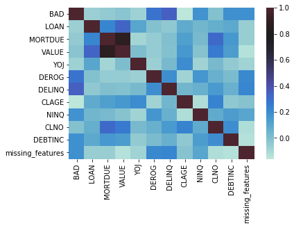

```python
sns.heatmap(df_train.corr(),center=0.8)  # heatmap of correlation matrix
```

```python
steps=[]    # adding info about each feature
```

## feature 1

```python
feature(df_train,['LOAN']).head()
```

|  | LOAN |
| --- | --- |
| 0 | 24100 |
| 1 | 14600 |
| 2 | 15400 |
| 3 | 12000 |
| 4 | 20200 |

```python
# % missing value in feature
perc_missing(df_train['LOAN'])
```

```
0.0
```

```python
# % correlation
correlation['LOAN']
```

```
-0.06696576587525242
```

```python
df_train['LOAN'].describe()
```

```
count     5006.000000
mean     18661.985617
std      11162.637981
min       1100.000000
25%      11100.000000
50%      16400.000000
75%      23400.000000
max      89900.000000
Name: LOAN, dtype: float64
```

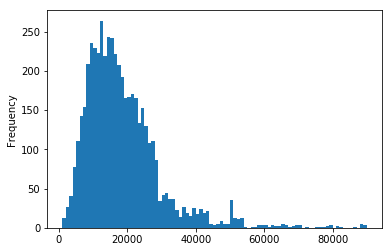

```python
df_train['LOAN'].plot.hist(bins=89)
```

```python
continous_distribution(df_train,'LOAN','BAD',10)
```

|  | LOAN_binned | count | no_default | %_default |
| --- | --- | --- | --- | --- |
| 0 | (1011.2, 9980.0] | 942 | 255 | 0.270701 |
| 1 | (9980.0, 18860.0] | 2063 | 394 | 0.190984 |
| 2 | (18860.0, 27740.0] | 1325 | 206 | 0.155472 |
| 3 | (27740.0, 36620.0] | 363 | 45 | 0.123967 |
| 4 | (36620.0, 45500.0] | 154 | 46 | 0.298701 |
| 5 | (45500.0, 54380.0] | 99 | 24 | 0.242424 |
| 6 | (54380.0, 63260.0] | 15 | 3 | 0.200000 |
| 7 | (63260.0, 72140.0] | 22 | 2 | 0.090909 |
| 8 | (72140.0, 81020.0] | 10 | 4 | 0.400000 |
| 9 | (81020.0, 89900.0] | 13 | 0 | 0.000000 |

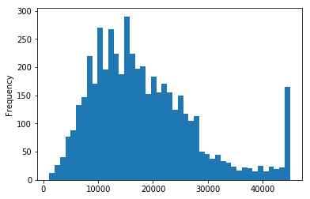

```python
#clipping
df_train['LOAN'].loc[df_train['LOAN']>=45000]=45000
df_test['LOAN'].loc[df_test['LOAN']>=45000]=45000
df_train['LOAN'].plot.hist(45)
```

```python
loan_bin=continous_distribution(df_train,'LOAN','BAD',9)
loan_bin
```

|  | LOAN_binned | count | no_default | %_default |
| --- | --- | --- | --- | --- |
| 0 | (1056.1, 5977.778] | 246 | 112 | 0.455285 |
| 1 | (5977.778, 10855.556] | 939 | 205 | 0.218317 |
| 2 | (10855.556, 15733.333] | 1165 | 243 | 0.208584 |
| 3 | (15733.333, 20611.111] | 957 | 151 | 0.157785 |
| 4 | (20611.111, 25488.889] | 755 | 110 | 0.145695 |
| 5 | (25488.889, 30366.667] | 431 | 55 | 0.127610 |
| 6 | (30366.667, 35244.444] | 169 | 21 | 0.124260 |
| 7 | (35244.444, 40122.222] | 99 | 28 | 0.282828 |
| 8 | (40122.222, 45000.0] | 245 | 54 | 0.220408 |

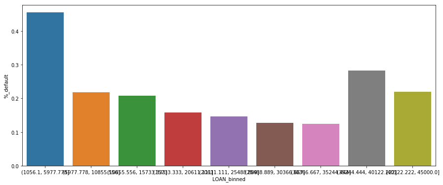

```python
plt.figure(figsize = (15, 6))
sns.barplot(data=loan_bin,x=loan_bin['LOAN_binned'],y=loan_bin['%_default'])
```

## feature_2

```python
feature(df_train,['MORTDUE']).head()
```

|  | MORTDUE |
| --- | --- |
| 0 | NaN |
| 1 | 54040.0 |
| 2 | 101981.0 |
| 3 | 114390.0 |
| 4 | 34676.0 |

```python
df_train['MORTDUE'].describe()
```

```
count      4573.000000
mean      74054.874719
std       45113.687889
min        2063.000000
25%       46124.000000
50%       65030.000000
75%       91731.000000
max      399550.000000
Name: MORTDUE, dtype: float64
```

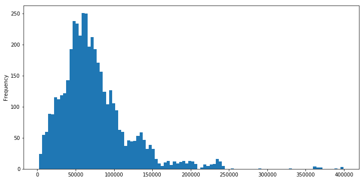

```python
plt.figure(figsize = (12, 6))
df_train['MORTDUE'].plot.hist(bins=100)
```

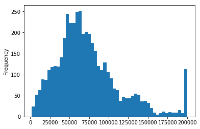

```python
#clipping
df_train['MORTDUE'].loc[df_train['MORTDUE']>=200000]=200000
df_test['MORTDUE'].loc[df_test['MORTDUE']>=200000]=200000
df_train['MORTDUE'].plot.hist(50)
```

```python
# correlation
correlation['MORTDUE']
```

```
-0.040994097807662014
```

```python
# % missing values
perc_missing(df_train['MORTDUE'])
```

```
8.649620455453455
```

```python
missing(df_train,'MORTDUE','BAD')
```

|  | is_null | %default | count | no_default |
| --- | --- | --- | --- | --- |
| 0 | False | 0.195714 | 4573 | 895 |
| 1 | True | 0.193995 | 433 | 84 |

```python
# impute missing values with mean
steps.append('f2 missing value with mean')
```

## feature 3

```python
feature(df_train,['VALUE']).head()
```

|  | VALUE |
| --- | --- |
| 0 | 49433.0 |
| 1 | 66442.0 |
| 2 | 145125.0 |
| 3 | 132800.0 |
| 4 | 62987.0 |

```python
df_train['VALUE'].describe()
```

```
count      4923.000000
mean     102247.468204
std       58509.252824
min        8000.000000
25%       66412.500000
50%       89421.000000
75%      119798.500000
max      855909.000000
Name: VALUE, dtype: float64
```

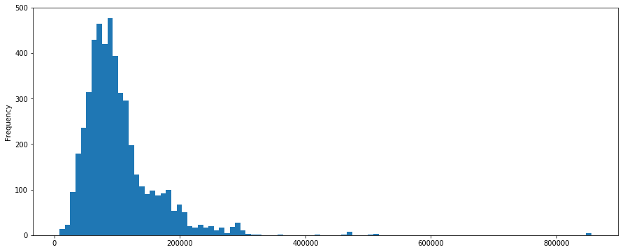

```python
plt.figure(figsize = (15, 6))
df_train['VALUE'].plot.hist(bins=100)
```

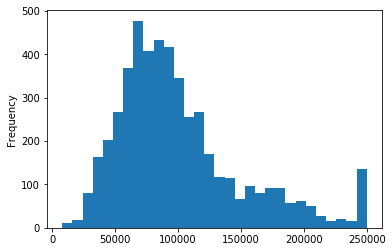

```python
#clipping
df_train['VALUE'].loc[df_train['VALUE']>=250000]=250000
df_test['VALUE'].loc[df_test['VALUE']>=250000]=250000
df_train['VALUE'].plot.hist(30)
```

```python
# correlation
correlation['VALUE']
```

```
-0.018121924819247147
```

```python
# % missing values
perc_missing(df_train['VALUE'])
```

```
1.658010387534958
```

```python
missing(df_train,'VALUE','BAD')
```

|  | is_null | %default | count | no_default |
| --- | --- | --- | --- | --- |
| 0 | False | 0.183018 | 4923 | 901 |
| 1 | True | 0.939759 | 83 | 78 |

```python
steps.append(['f3 new_col null_value','f3 fill missing with mean'])
```

## feature 4

```python
feature(df_train,['REASON']).head()
```

|  | REASON |
| --- | --- |
| 0 | DebtCon |
| 1 | DebtCon |
| 2 | DebtCon |
| 3 | DebtCon |
| 4 | DebtCon |

```python
df_train['REASON'].describe()
```

```
count        4800
unique          2
top       DebtCon
freq         3315
Name: REASON, dtype: object
```

```python
pd.unique(df_train['REASON'])
```

```
array(['DebtCon', nan, 'HomeImp'], dtype=object)
```

```python
categorical_distribution(df_train,'REASON','BAD')
```

|  | REASON | count | no_default | %default |
| --- | --- | --- | --- | --- |
| 0 | DebtCon | 3315 | 617 | 0.186124 |
| 1 | HomeImp | 1485 | 328 | 0.220875 |

```python
## missing value
perc_missing(df_train['REASON'])
```

```
4.115061925689173
```

```python
missing(df_train,'REASON','BAD')
```

|  | is_null | %default | count | no_default |
| --- | --- | --- | --- | --- |
| 0 | False | 0.196875 | 4800 | 945 |
| 1 | True | 0.165049 | 206 | 34 |

```python
steps.append(['f4 col imputer with missing','f4 one encoder'])
```

## feature 5

```python
feature(df_train,['JOB']).head()
```

|  | JOB |
| --- | --- |
| 0 | Other |
| 1 | Other |
| 2 | Office |
| 3 | Mgr |
| 4 | Other |

```python
df_train['JOB'].describe()
```

```
count      4779
unique        6
top       Other
freq       2001
Name: JOB, dtype: object
```

```python
pd.unique(df_train['JOB'])
```

```
array(['Other', 'Office', 'Mgr', 'ProfExe', 'Self', nan, 'Sales'],
      dtype=object)
```

```python
# missing values
perc_missing(df_train['JOB'])
```

```
4.534558529764283
```

```python
categorical_distribution(df_train,'JOB','BAD').sort_values(by='%default')
```

|  | JOB | count | no_default | %default |
| --- | --- | --- | --- | --- |
| 1 | Office | 791 | 101 | 0.127686 |
| 3 | ProfExe | 1079 | 178 | 0.164968 |
| 0 | Mgr | 648 | 137 | 0.211420 |
| 2 | Other | 2001 | 462 | 0.230885 |
| 5 | Self | 167 | 49 | 0.293413 |
| 4 | Sales | 93 | 33 | 0.354839 |

```python
missing(df_train,'JOB','BAD')
```

|  | is_null | %default | count | no_default |
| --- | --- | --- | --- | --- |
| 0 | False | 0.200879 | 4779 | 960 |
| 1 | True | 0.083700 | 227 | 19 |

```python
steps.append(['f5 col imputer missing','f5 one encoder'])
```

## feature 6

```python
feature(df_train,['YOJ']).head()
```

|  | YOJ |
| --- | --- |
| 0 | NaN |
| 1 | 6.0 |
| 2 | 3.0 |
| 3 | 10.0 |
| 4 | 1.0 |

```python
df_train['YOJ'].describe()
```

```
count    4581.000000
mean        8.919919
std         7.605938
min         0.000000
25%         3.000000
50%         7.000000
75%        13.000000
max        41.000000
Name: YOJ, dtype: float64
```

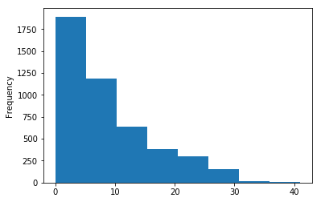

```python
plt.figure(figsize = (6, 4))
df_train['YOJ'].plot.hist(bins=8)
```

```python
continous_distribution(df_train,'YOJ','BAD',8)
```

|  | YOJ_binned | count | no_default | %_default |
| --- | --- | --- | --- | --- |
| 0 | (-0.041, 5.125] | 1894 | 453 | 0.239176 |
| 1 | (5.125, 10.25] | 1189 | 212 | 0.178301 |
| 2 | (10.25, 15.375] | 640 | 135 | 0.210938 |
| 3 | (15.375, 20.5] | 383 | 75 | 0.195822 |
| 4 | (20.5, 25.625] | 297 | 31 | 0.104377 |
| 5 | (25.625, 30.75] | 152 | 16 | 0.105263 |
| 6 | (30.75, 35.875] | 18 | 2 | 0.111111 |
| 7 | (35.875, 41.0] | 8 | 3 | 0.375000 |

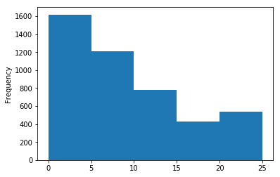

```python
#clipping
df_train['YOJ'].loc[df_train['YOJ']>=25]=25
df_test['YOJ'].loc[df_test['YOJ']>=25]=25
df_train['YOJ'].plot.hist(5)
```

```python
## corelation with class
correlation['YOJ']
```

```
-0.07415361194940825
```

```python
## missing values
perc_missing(df_train['YOJ'])
```

```
8.489812225329604
```

```python
missing(df_train,'YOJ','BAD')
```

|  | is_null | %default | count | no_default |
| --- | --- | --- | --- | --- |
| 0 | False | 0.202358 | 4581 | 927 |
| 1 | True | 0.122353 | 425 | 52 |

```python
steps.append(['f6 new col is_null','f6 col imputer by mean'])
```

## feature 7

```python
feature(df_train,['DEROG']).head()
```

|  | DEROG |
| --- | --- |
| 0 | NaN |
| 1 | 0.0 |
| 2 | NaN |
| 3 | 0.0 |
| 4 | 0.0 |

```python
df_train['DEROG'].describe()
```

```
count    4430.000000
mean        0.254628
std         0.842908
min         0.000000
25%         0.000000
50%         0.000000
75%         0.000000
max        10.000000
Name: DEROG, dtype: float64
```

```python
pd.unique(df_train['DEROG'])
```

```
array([nan,  0.,  6.,  1.,  2.,  7.,  3.,  9.,  8.,  4.,  5., 10.])
```

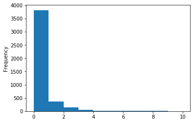

```python
df_train['DEROG'].plot.hist(bins=10)
```

```python
# correlation
correlation['DEROG']
```

```
0.2863870219680702
```

```python
categorical_distribution(df_train,'DEROG','BAD')
```

|  | DEROG | count | no_default | %default |
| --- | --- | --- | --- | --- |
| 0 | 0.0 | 3818 | 625 | 0.163698 |
| 1 | 1.0 | 367 | 140 | 0.381471 |
| 2 | 2.0 | 136 | 72 | 0.529412 |
| 3 | 3.0 | 46 | 34 | 0.739130 |
| 4 | 4.0 | 22 | 17 | 0.772727 |
| 5 | 5.0 | 12 | 7 | 0.583333 |
| 6 | 6.0 | 13 | 9 | 0.692308 |
| 7 | 7.0 | 7 | 7 | 1.000000 |
| 8 | 8.0 | 6 | 6 | 1.000000 |
| 9 | 9.0 | 2 | 2 | 1.000000 |
| 10 | 10.0 | 1 | 1 | 1.000000 |

```python
#clipping
df_train['DEROG'].loc[df_train['DEROG']>=3]=3
df_test['DEROG'].loc[df_test['DEROG']>=3]=3
```

```python
derog_bins_new=categorical_distribution(df_train,'DEROG','BAD')
derog_bins_new
```

|  | DEROG | count | no_default | %default |
| --- | --- | --- | --- | --- |
| 0 | 0.0 | 3818 | 625 | 0.163698 |
| 1 | 1.0 | 367 | 140 | 0.381471 |
| 2 | 2.0 | 136 | 72 | 0.529412 |
| 3 | 3.0 | 109 | 83 | 0.761468 |

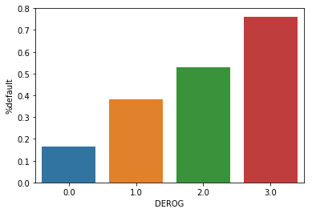

```python
sns.barplot(data=derog_bins_new,x='DEROG',y='%default')
```

```python
# missing data
perc_missing(df_train['DEROG'])
```

```
11.5061925689173
```

```python
missing(df_train,'DEROG','BAD')
```

|  | is_null | %default | count | no_default |
| --- | --- | --- | --- | --- |
| 0 | False | 0.207675 | 4430 | 920 |
| 1 | True | 0.102431 | 576 | 59 |

```python
steps.append('f7 col imputer with -1')
```

## feature 8

Number of delinquent credit lines

```python
feature(df_train,['DELINQ']).head()
```

|  | DELINQ |
| --- | --- |
| 0 | NaN |
| 1 | 0.0 |
| 2 | NaN |
| 3 | 0.0 |
| 4 | 0.0 |

```python
df_train['DELINQ'].describe()
```

```
count    4530.000000
mean        0.428918
std         1.081735
min         0.000000
25%         0.000000
50%         0.000000
75%         0.000000
max        12.000000
Name: DELINQ, dtype: float64
```

```python
pd.unique(df_train['DELINQ'])
```

```
array([nan,  0.,  3.,  2.,  4.,  1.,  5.,  6.,  7., 11.,  8., 12., 10.])
```

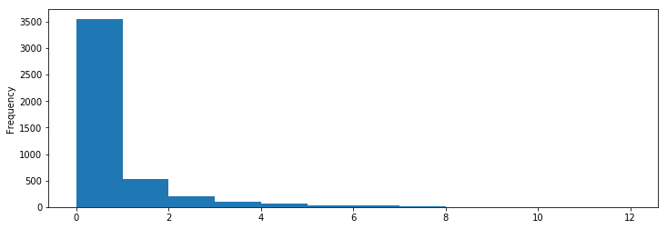

```python
plt.figure(figsize = (12, 4))
df_train['DELINQ'].plot.hist(bins=12)
```

```python
# correlation
correlation['DELINQ']
```

```
0.34839958989311487
```

```python
# missing values
perc_missing(df_train['DELINQ'])
```

```
9.508589692369156
```

```python
categorical_distribution(df_train,'DELINQ','BAD')
```

|  | DELINQ | count | no_default | %default |
| --- | --- | --- | --- | --- |
| 0 | 0.0 | 3553 | 499 | 0.140445 |
| 1 | 1.0 | 532 | 177 | 0.332707 |
| 2 | 2.0 | 210 | 96 | 0.457143 |
| 3 | 3.0 | 103 | 53 | 0.514563 |
| 4 | 4.0 | 59 | 37 | 0.627119 |
| 5 | 5.0 | 30 | 23 | 0.766667 |
| 6 | 6.0 | 26 | 26 | 1.000000 |
| 7 | 7.0 | 10 | 10 | 1.000000 |
| 8 | 8.0 | 2 | 2 | 1.000000 |
| 9 | 10.0 | 2 | 2 | 1.000000 |
| 10 | 11.0 | 2 | 2 | 1.000000 |
| 11 | 12.0 | 1 | 1 | 1.000000 |

```python
#clipping
df_train['DELINQ'].loc[df_train['DELINQ']>=3]=3
df_test['DELINQ'].loc[df_test['DELINQ']>=3]=3
```

```python
delinq_bins_new=categorical_distribution(df_train,'DELINQ','BAD')
delinq_bins_new
```

|  | DELINQ | count | no_default | %default |
| --- | --- | --- | --- | --- |
| 0 | 0.0 | 3553 | 499 | 0.140445 |
| 1 | 1.0 | 532 | 177 | 0.332707 |
| 2 | 2.0 | 210 | 96 | 0.457143 |
| 3 | 3.0 | 235 | 156 | 0.663830 |

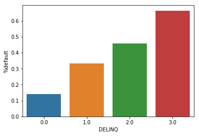

```python
sns.barplot(data=delinq_bins_new,x='DELINQ',y='%default')
```

```python
missing(df_train,'DELINQ','BAD')
```

|  | is_null | %default | count | no_default |
| --- | --- | --- | --- | --- |
| 0 | False | 0.204857 | 4530 | 928 |
| 1 | True | 0.107143 | 476 | 51 |

```python
## as we can see that people whose DELINQ reports are missing default less from all in %
## so we will impute with -1
steps.append('f8 col imputer -1')
```

## feature 9

Age of oldest trade line in months. A trade line is a record of activity for any type of credit extended to a borrower and reported to a credit reporting agency.

```python
feature_9=feature(df_train,['CLAGE','BAD'])
feature_9.head()
```

|  | CLAGE | BAD |
| --- | --- | --- |
| 0 | 83.099726 | 0 |
| 1 | 237.599254 | 0 |
| 2 | 105.552570 | 0 |
| 3 | 95.733333 | 1 |
| 4 | 112.799087 | 0 |

```python
df_train['CLAGE'].describe()
```

```
count    4761.000000
mean      179.862827
std        86.603696
min         0.000000
25%       114.600000
50%       173.318321
75%       232.236996
max      1168.233561
Name: CLAGE, dtype: float64
```

```python
df_train.loc[:,'CLAGE']=(df_train[['CLAGE']]/12).to_numpy()## in years
df_test.loc[:,'CLAGE']=(df_test[['CLAGE']]/12).to_numpy()
```

```python
df_train['CLAGE'].describe()
```

```
count    4761.000000
mean       14.988569
std         7.216975
min         0.000000
25%         9.550000
50%        14.443193
75%        19.353083
max        97.352797
Name: CLAGE, dtype: float64
```

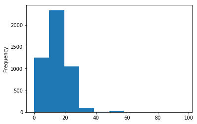

```python
df_train['CLAGE'].plot.hist(bins=10)
```

```python
# correlation
correlation['CLAGE']
```

```
-0.16036206556411978
```

```python
# missing values
perc_missing(df_train['CLAGE'])
```

```
4.894127047542948
```

```python
continous_distribution(df_train,'CLAGE','BAD',10)
```

|  | CLAGE_binned | count | no_default | %_default |
| --- | --- | --- | --- | --- |
| 0 | (-0.0974, 9.735] | 1252 | 347 | 0.277157 |
| 1 | (9.735, 19.471] | 2339 | 452 | 0.193245 |
| 2 | (19.471, 29.206] | 1051 | 109 | 0.103711 |
| 3 | (29.206, 38.941] | 92 | 9 | 0.097826 |
| 4 | (38.941, 48.676] | 8 | 1 | 0.125000 |
| 5 | (48.676, 58.412] | 17 | 0 | 0.000000 |
| 6 | (58.412, 68.147] | 0 | 0 | NaN |
| 7 | (68.147, 77.882] | 0 | 0 | NaN |
| 8 | (77.882, 87.618] | 0 | 0 | NaN |
| 9 | (87.618, 97.353] | 2 | 2 | 1.000000 |

```python
#clipping
df_train['CLAGE'].loc[df_train['CLAGE']>=29]=29
df_test['CLAGE'].loc[df_test['CLAGE']>=29]=29
```

```python
clage_bins_new=continous_distribution(df_train,'CLAGE','BAD',3)
clage_bins_new
```

|  | CLAGE_binned | count | no_default | %_default |
| --- | --- | --- | --- | --- |
| 0 | (-0.029, 9.667] | 1230 | 344 | 0.279675 |
| 1 | (9.667, 19.333] | 2337 | 452 | 0.193410 |
| 2 | (19.333, 29.0] | 1194 | 124 | 0.103853 |

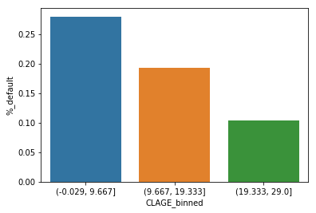

```python
sns.barplot(data=clage_bins_new,x='CLAGE_binned',y='%_default')
```

```python
missing(df_train,'CLAGE','BAD')
```

|  | is_null | %default | count | no_default |
| --- | --- | --- | --- | --- |
| 0 | False | 0.193237 | 4761 | 920 |
| 1 | True | 0.240816 | 245 | 59 |

```python
steps.append('f9 col imputer mean')
```

## feature 10

Number of recent credit lines

```python
feature(df_train,['NINQ']).head()
```

|  | NINQ |
| --- | --- |
| 0 | NaN |
| 1 | 0.0 |
| 2 | 3.0 |
| 3 | 0.0 |
| 4 | 0.0 |

```python
df_train['NINQ'].describe()
```

```
count    4590.000000
mean        1.186275
std         1.741132
min         0.000000
25%         0.000000
50%         1.000000
75%         2.000000
max        17.000000
Name: NINQ, dtype: float64
```

```python
pd.unique(df_train['NINQ'])
```

```
array([nan,  0.,  3.,  1.,  2.,  7.,  4.,  8.,  5., 11.,  6., 10.,  9.,
       13., 12., 17.])
```

```python
# correlation
correlation['NINQ']
```

```
0.18396536811431252
```

```python
# missing values
perc_missing(df_train['NINQ'])
```

```
8.310027966440272
```

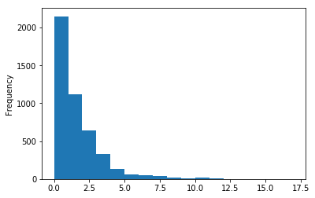

```python
df_train['NINQ'].plot.hist(bins=17)
```

```python
categorical_distribution(df_train,'NINQ','BAD')
```

|  | NINQ | count | no_default | %default |
| --- | --- | --- | --- | --- |
| 0 | 0.0 | 2148 | 322 | 0.149907 |
| 1 | 1.0 | 1121 | 215 | 0.191793 |
| 2 | 2.0 | 643 | 148 | 0.230171 |
| 3 | 3.0 | 326 | 87 | 0.266871 |
| 4 | 4.0 | 136 | 51 | 0.375000 |
| 5 | 5.0 | 61 | 31 | 0.508197 |
| 6 | 6.0 | 51 | 27 | 0.529412 |
| 7 | 7.0 | 37 | 13 | 0.351351 |
| 8 | 8.0 | 20 | 11 | 0.550000 |
| 9 | 9.0 | 10 | 5 | 0.500000 |
| 10 | 10.0 | 23 | 7 | 0.304348 |
| 11 | 11.0 | 9 | 3 | 0.333333 |
| 12 | 12.0 | 2 | 2 | 1.000000 |
| 13 | 13.0 | 2 | 2 | 1.000000 |
| 14 | 17.0 | 1 | 1 | 1.000000 |

```python
#clipping
df_train['NINQ'].loc[df_train['NINQ']>=4]=4
df_test['NINQ'].loc[df_test['NINQ']>=4]=4
```

```python
ninq_bins_new=categorical_distribution(df_train,'NINQ','BAD')
ninq_bins_new
```

|  | NINQ | count | no_default | %default |
| --- | --- | --- | --- | --- |
| 0 | 0.0 | 2148 | 322 | 0.149907 |
| 1 | 1.0 | 1121 | 215 | 0.191793 |
| 2 | 2.0 | 643 | 148 | 0.230171 |
| 3 | 3.0 | 326 | 87 | 0.266871 |
| 4 | 4.0 | 352 | 153 | 0.434659 |

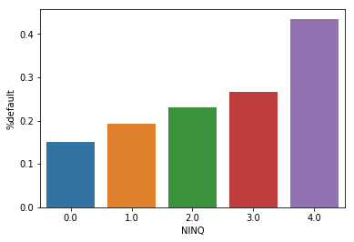

```python
sns.barplot(data=ninq_bins_new,x='NINQ',y='%default')
```

```python
## null values
missing(df_train,'NINQ','BAD')
```

|  | is_null | %default | count | no_default |
| --- | --- | --- | --- | --- |
| 0 | False | 0.201525 | 4590 | 925 |
| 1 | True | 0.129808 | 416 | 54 |

```python
## as we can see that people whose NINQ reports are missing default less from all in %
## so we will impute with -1
steps.append('f10 col imputer with -1')
```

## feature 11

Number of credit lines

```python
feature(df_train,['CLNO']).head()
```

|  | CLNO |
| --- | --- |
| 0 | 13.0 |
| 1 | 18.0 |
| 2 | 15.0 |
| 3 | 25.0 |
| 4 | 17.0 |

```python
df_train['CLNO'].describe()
```

```
count    4833.000000
mean       21.253259
std        10.056566
min         0.000000
25%        15.000000
50%        20.000000
75%        26.000000
max        71.000000
Name: CLNO, dtype: float64
```

```python
correlation['CLNO']
```

```
-0.006055155862493749
```

```python
perc_missing(df_train['CLNO'])
```

```
3.455852976428286
```

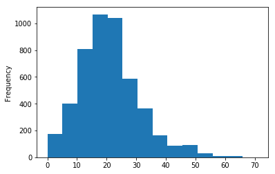

```python
df_train['CLNO'].plot.hist(bins=14)
```

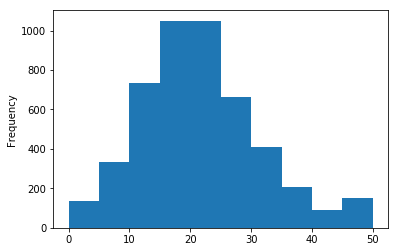

```python
#clipping
df_train['CLNO'].loc[df_train['CLNO']>=50]=50
df_test['CLNO'].loc[df_test['CLNO']>=50]=50
df_train['CLNO'].plot.hist(bins=10)
```

```python
## null values
missing(df_train,'CLNO','BAD')
```

|  | is_null | %default | count | no_default |
| --- | --- | --- | --- | --- |
| 0 | False | 0.194910 | 4833 | 942 |
| 1 | True | 0.213873 | 173 | 37 |

```python
steps.append('f11 col imputer with mean')
```

## feature 12

Debt to income ratio

```python
feature(df_train,['DEBTINC']).head()
```

|  | DEBTINC |
| --- | --- |
| 0 | 26.148970 |
| 1 | 34.883435 |
| 2 | 32.699440 |
| 3 | NaN |
| 4 | 22.093046 |

```python
df_train['DEBTINC'].describe()
```

```
count    3954.000000
mean       33.660950
std         8.367357
min         0.524499
25%        29.015212
50%        34.743796
75%        38.998215
max       144.189001
Name: DEBTINC, dtype: float64
```

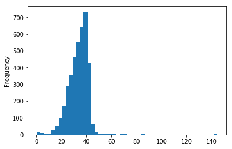

```python
df_train['DEBTINC'].plot.hist(bins=50)
```

```python
correlation['DEBTINC']
```

```
0.19224272998943667
```

```python
perc_missing(df_train['DEBTINC']) ## as correlation is good so dropping this column is a bad idea
```

```
21.014782261286456
```

```python
continous_distribution(df_train,'DEBTINC','BAD',16)
```

|  | DEBTINC_binned | count | no_default | %_default |
| --- | --- | --- | --- | --- |
| 0 | (0.381, 9.504] | 29 | 11 | 0.379310 |
| 1 | (9.504, 18.483] | 97 | 6 | 0.061856 |
| 2 | (18.483, 27.462] | 663 | 29 | 0.043741 |
| 3 | (27.462, 36.441] | 1564 | 90 | 0.057545 |
| 4 | (36.441, 45.42] | 1545 | 138 | 0.089320 |
| 5 | (45.42, 54.399] | 31 | 30 | 0.967742 |
| 6 | (54.399, 63.378] | 10 | 10 | 1.000000 |
| 7 | (63.378, 72.357] | 5 | 5 | 1.000000 |
| 8 | (72.357, 81.336] | 3 | 3 | 1.000000 |
| 9 | (81.336, 90.315] | 2 | 2 | 1.000000 |
| 10 | (90.315, 99.294] | 1 | 1 | 1.000000 |
| 11 | (99.294, 108.273] | 0 | 0 | NaN |
| 12 | (108.273, 117.252] | 1 | 1 | 1.000000 |
| 13 | (117.252, 126.231] | 0 | 0 | NaN |
| 14 | (126.231, 135.21] | 1 | 1 | 1.000000 |
| 15 | (135.21, 144.189] | 2 | 2 | 1.000000 |

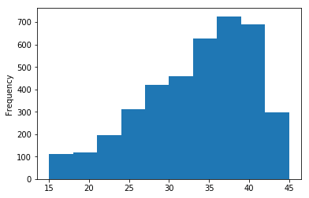

```python
#clipping
df_train['DEBTINC'].loc[df_train['DEBTINC']>=45]=45
df_test['DEBTINC'].loc[df_test['DEBTINC']>=45]=45

df_train['DEBTINC'].loc[df_train['DEBTINC']<=15]=15
df_test['DEBTINC'].loc[df_test['DEBTINC']<=15]=15

df_train['DEBTINC'].plot.hist(bins=10)
```

```python
continous_distribution(df_train,'DEBTINC','BAD',16)
```

|  | DEBTINC_binned | count | no_default | %_default |
| --- | --- | --- | --- | --- |
| 0 | (14.97, 16.875] | 99 | 15 | 0.151515 |
| 1 | (16.875, 18.75] | 33 | 2 | 0.060606 |
| 2 | (18.75, 20.625] | 75 | 1 | 0.013333 |
| 3 | (20.625, 22.5] | 113 | 5 | 0.044248 |
| 4 | (22.5, 24.375] | 137 | 6 | 0.043796 |
| 5 | (24.375, 26.25] | 193 | 11 | 0.056995 |
| 6 | (26.25, 28.125] | 232 | 11 | 0.047414 |
| 7 | (28.125, 30.0] | 273 | 11 | 0.040293 |
| 8 | (30.0, 31.875] | 296 | 17 | 0.057432 |
| 9 | (31.875, 33.75] | 314 | 17 | 0.054140 |
| 10 | (33.75, 35.625] | 402 | 24 | 0.059701 |
| 11 | (35.625, 37.5] | 420 | 35 | 0.083333 |
| 12 | (37.5, 39.375] | 464 | 28 | 0.060345 |
| 13 | (39.375, 41.25] | 479 | 36 | 0.075157 |
| 14 | (41.25, 43.125] | 265 | 27 | 0.101887 |
| 15 | (43.125, 45.0] | 159 | 83 | 0.522013 |

```python
df_train_debtinc=copy.deepcopy(df_train[['DEBTINC']])
df_test_debtinc=copy.deepcopy(df_test[['DEBTINC']])

df_train['DEBTINC'].loc[df_train_debtinc['DEBTINC']<=17]='low'
df_test['DEBTINC'].loc[df_test_debtinc['DEBTINC']<=17]='low'

df_train['DEBTINC'].loc[(df_train_debtinc['DEBTINC']>17) & (df_train_debtinc['DEBTINC']<43)]='med'
df_test['DEBTINC'].loc[(df_test_debtinc['DEBTINC']>17) & (df_test_debtinc['DEBTINC']<43)]='med'

df_train['DEBTINC'].loc[df_train_debtinc['DEBTINC']>=43]='high'
df_test['DEBTINC'].loc[df_test_debtinc['DEBTINC']>=43]='high'
```

```python
categorical_distribution(df_train,'DEBTINC','BAD')
```

|  | DEBTINC | count | no_default | %default |
| --- | --- | --- | --- | --- |
| 0 | high | 172 | 85 | 0.494186 |
| 1 | low | 100 | 16 | 0.160000 |
| 2 | med | 3682 | 228 | 0.061923 |

```python
## null values
missing(df_train,'DEBTINC','BAD')
```

|  | is_null | %default | count | no_default |
| --- | --- | --- | --- | --- |
| 0 | False | 0.083207 | 3954 | 329 |
| 1 | True | 0.617871 | 1052 | 650 |

```python
steps.append(['f12 impute missing with missing,f12 with one hot encoder'])
```

#### functions

```python
from confusion_matrix import print_confusion_matrix
from Metrics import metrics

def evaluation_metrics(cf,z):
    gbt_metrics_test = metrics(cf)
    print ('<<<<<<<<<<<<'+z+' METRICS >>>>>>>>>>>>>')
    print ('accuracy : ',(cf[0][0]+cf[1][1])/np.sum(cf))
    #print '\n'
    print ('=================class_0==================')
    print ('fMeasure_of_class_0 : ',gbt_metrics_test.f_measure(0))
    print ('precision_of_class_0: ',gbt_metrics_test.precision(0))
    print ('recall_of_class_0:    ',gbt_metrics_test.recall(0))

    #print '\n'
    print ('=================class_1==================')
    print ('fMeasure_of_class_1 : ',gbt_metrics_test.f_measure(1))
    print ('precision_of_class_1: ',gbt_metrics_test.precision(1))
    print ('recall_of_class_1:    ',gbt_metrics_test.recall(1))

    print_confusion_matrix(cf,'cf',3)
```

```python
def choose_threshold(true_y,pred_prob):
    sorted_true=pd.DataFrame(list(zip(true_y,pred_prob))).sort_values(by=1,ascending=False).reset_index(drop=True)
    max_f1=0
    recall=0
    precision=0
    for i in range(len(sorted_true)):
        sorted_true[2]=(sorted_true[1]>=sorted_true.iloc[i][1]).astype(int)
        temp_f1=f1_score(sorted_true[0],sorted_true[2])
        if(temp_f1>max_f1):
            max_f1=temp_f1
            precision=precision_score(sorted_true[0],sorted_true[2])
            recall=recall_score(sorted_true[0],sorted_true[2])
            best_threshold=sorted_true.iloc[i][1]
    return max_f1,precision,recall,best_threshold


def DEBTINC_imputer(row):
      if (row>0)==False:
        return np.random.uniform(low=0.5, high=150)
      else:
        return row
```

#### training_Testing X_Y Split

```python
X=df_train.drop('BAD',axis=1)
Y=df_train['BAD']

test_x=df_test.drop('BAD',axis=1)
test_y=df_test['BAD']
```

### K-fold cross validation

```python
from sklearn.ensemble import RandomForestClassifier
from sklearn.metrics import roc_auc_score
from sklearn.metrics import f1_score,roc_curve,precision_score,recall_score
from sklearn.metrics import confusion_matrix
from sklearn.model_selection import KFold
from sklearn.preprocessing import OneHotEncoder
```

```python
steps
```

```
['f2 missing value with mean',
 ['f3 new_col null_value', 'f3 fill missing with mean'],
 ['f4 col imputer with missing', 'f4 one encoder'],
 ['f5 col imputer missing', 'f5 one encoder'],
 ['f6 new col is_null', 'f6 col imputer by mean'],
 'f7 col imputer with -1',
 'f8 col imputer -1',
 'f9 col imputer mean',
 'f10 col imputer with -1',
 'f11 col imputer with mean',
 ['f12 impute missing with missing,f12 with one hot encoder']]
```

```python
column_names
```

```
Index(['BAD', 'LOAN', 'MORTDUE', 'VALUE', 'REASON', 'JOB', 'YOJ', 'DEROG',
       'DELINQ', 'CLAGE', 'NINQ', 'CLNO', 'DEBTINC', 'missing_features'],
      dtype='object')
```

```python
col_imputer(X,[X,test_x],'REASON','missing') #4
one_hot_encoder(X,[X,test_x],'REASON')
X=X.drop('REASON',axis=1)
test_x=test_x.drop('REASON',axis=1)

col_imputer(X,[X,test_x],'JOB','missing') #5
one_hot_encoder(X,[X,test_x],'JOB')
X=X.drop('JOB',axis=1)
test_x=test_x.drop('JOB',axis=1)

col_imputer(X,[X,test_x],'DEROG',-1)   #7

col_imputer(X,[X,test_x],'DELINQ',-1)  #8

col_imputer(X,[X,test_x],'NINQ',-1)   #10

col_imputer(X,[X,test_x],'DEBTINC','missing') #12
one_hot_encoder(X,[X,test_x],'DEBTINC')
X=X.drop('DEBTINC',axis=1)
test_x=test_x.drop('DEBTINC',axis=1)

# changes which can me made on all data sets training/val/testing simultaneously
```

```python
def fit_transform(fit_df,transform_dfs):

    col_imputer(fit_df,transform_dfs,'MORTDUE',fit_df['MORTDUE'].mean()) #2

    is_null_new_column(fit_df,transform_dfs,'VALUE') #3
    col_imputer(fit_df,transform_dfs,'VALUE',fit_df['VALUE'].mean())

    is_null_new_column(fit_df,transform_dfs,'YOJ')               #6
    col_imputer(fit_df,transform_dfs,'YOJ',fit_df['YOJ'].mean())

    col_imputer(fit_df,transform_dfs,'CLAGE',fit_df['CLAGE'].mean())  #9

    col_imputer(fit_df,transform_dfs,'CLNO',fit_df['CLNO'].mean())  #11


# changes than can only be made with training data on val/test data
```

```python
kf = KFold(n_splits=10,shuffle=True,random_state=0)

clf = RandomForestClassifier(n_estimators=100
                             ,max_features='auto'
                             ,max_depth=None
                             ,criterion='entropy'
                             ,oob_score=True
                             #,verbose=10
                             #,min_samples_split=20
                             ,min_samples_leaf=1
                             ,random_state=0
                             ,class_weight={0:1, 1:1})
```

```python
auc_sum_train=0
auc_sum_val=0
fold_no=1
f1=0
precision=0
recall=0
thershold=0
for train_index, test_index in kf.split(df_train):
    x_train, x_val = X.iloc[train_index], X.iloc[test_index]
    y_train, y_val = Y.iloc[train_index], Y.iloc[test_index]


    fit_transform(x_train,[x_train,x_val])

    clf.fit(x_train,y_train)

    print('fold:',fold_no
          ,' AUC_training: ',roc_auc_score(y_train,clf.predict_proba(x_train)[:,1])
          ,' AUC_val: ',roc_auc_score(y_val,clf.predict_proba(x_val)[:,1]))

    auc_sum_train+=roc_auc_score(y_train,clf.predict_proba(x_train)[:,1])
    auc_sum_val+=roc_auc_score(y_val,clf.predict_proba(x_val)[:,1])
    '''
    f,p,r,t=choose_threshold(y_val,clf.predict_proba(x_val)[:,1])
    f1=f1+f
    precision+=p
    recall+=r
    thershold+=t
    print('-------------------------------')
    print('f1_max: ',f,' thershold: ',t)
    print('precision: ',p,' recall: ',r)
    '''
    print('===============================')
    fold_no+=1

avg_auc_train=auc_sum_train/kf.get_n_splits()
avg_auc_val=auc_sum_val/kf.get_n_splits()
avg_f1=f1/kf.get_n_splits()
avg_precision=precision/kf.get_n_splits()
avg_recall=recall/kf.get_n_splits()
avg_thershold=thershold/kf.get_n_splits()
print('#####################################')
print('avg_auc_train: ',avg_auc_train)
print('avg_auc_val: ',avg_auc_val)
#print('avg_f1_val: ',avg_f1)
#print('avg_precision_val: ',avg_precision)
#print('avg_recall_val: ',avg_recall)
#print('avg_thershold_val: ',avg_thershold)
```

```
fold: 1  AUC_training:  1.0  AUC_val:  0.9685939119781359
===============================
fold: 2  AUC_training:  1.0  AUC_val:  0.9455015944377647
===============================
fold: 3  AUC_training:  1.0  AUC_val:  0.9452668225789306
===============================
fold: 4  AUC_training:  1.0  AUC_val:  0.9702083554799616
===============================
fold: 5  AUC_training:  1.0  AUC_val:  0.9542606516290726
===============================
fold: 6  AUC_training:  1.0  AUC_val:  0.9578505368342723
===============================
fold: 7  AUC_training:  1.0  AUC_val:  0.9554756849402677
===============================
fold: 8  AUC_training:  1.0  AUC_val:  0.9626611838765357
===============================
fold: 9  AUC_training:  1.0  AUC_val:  0.9535954567547517
===============================
fold: 10  AUC_training:  1.0  AUC_val:  0.9526527312073435
===============================
#####################################
avg_auc_train:  1.0
avg_auc_val:  0.9566066929717039
```

```python
clf.get_params
```

```
<bound method BaseEstimator.get_params of RandomForestClassifier(bootstrap=True, class_weight={0: 1, 1: 1},
                       criterion='entropy', max_depth=None, max_features='auto',
                       max_leaf_nodes=None, min_impurity_decrease=0.0,
                       min_impurity_split=None, min_samples_leaf=1,
                       min_samples_split=2, min_weight_fraction_leaf=0.0,
                       n_estimators=100, n_jobs=None, oob_score=True,
                       random_state=0, verbose=0, warm_start=False)>
```

### performance on test dataset

```python
### on test dataset
x_train=copy.deepcopy(X)
y_train=copy.deepcopy(Y)

x_test=copy.deepcopy(test_x)
y_test=copy.deepcopy(test_y)
```

```python
fit_transform(x_train,[x_train,x_test])
```

```python
clf.fit(x_train,y_train)
print('AUC_train: ',roc_auc_score(y_train,clf.predict_proba(x_train)[:,1]))
print('AUC_test: ',roc_auc_score(y_test,clf.predict_proba(x_test)[:,1]))
```

```
AUC_train:  1.0
AUC_test:  0.9659114183307732
```

```python
t=choose_threshold(y_test,clf.predict_proba(x_test)[:,1])[3] # select thershold from prob to get best f1 score
```

```
<<<<<<<<<<<<TESTING METRICS >>>>>>>>>>>>>
accuracy :  0.9182389937106918
=================class_0==================
fMeasure_of_class_0 :  0.9471544715447154
precision_of_class_0:  0.9549180327868853
recall_of_class_0:     0.9395161290322581
=================class_1==================
fMeasure_of_class_1 :  0.8194444444444444
precision_of_class_1:  0.7972972972972973
recall_of_class_1:     0.8428571428571429
```

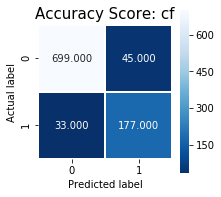

```python
predict_test_y=(clf.predict_proba(x_test)[:,1]>=t).astype(int)
cf_test=confusion_matrix(y_test,predict_test_y)
evaluation_metrics(cf_test,'TESTING')
```

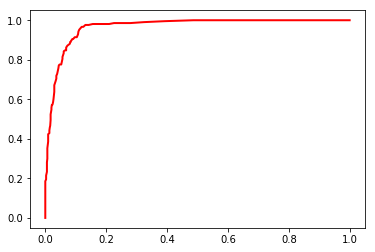

```python
z=roc_curve(y_test,clf.predict_proba(x_test)[:,1])
y=roc_curve(y_train,clf.predict_proba(x_train)[:,1])

plt. plot(z[0], z[1], linewidth=2.0,color='red',label='test') # test-REd
#plt. plot(y[0], y[1], linewidth=2.0,color='blue',label='train') #train-BLUE
# roc curve train/testing
```

## Model Analysis

```python
feature_importance=pd.DataFrame(list(zip(clf.feature_importances_*100,x_train.columns))).sort_values(by=0,ascending=False)
feature_importance=feature_importance.rename({0:'feature_imp',1:'feature'},axis=1).reset_index(drop=True)
feature_importance
```

|  | feature_imp | feature |
| --- | --- | --- |
| 0 | 13.390705 | DEBTINC_med |
| 1 | 10.193751 | DEBTINC_missing |
| 2 | 9.721074 | CLAGE |
| 3 | 7.977822 | LOAN |
| 4 | 7.754846 | VALUE |
| 5 | 7.576760 | CLNO |
| 6 | 7.302643 | MORTDUE |
| 7 | 6.311014 | YOJ |
| 8 | 6.120895 | DELINQ |
| 9 | 4.370670 | DEROG |
| 10 | 3.777547 | NINQ |
| 11 | 3.629345 | missing_features |
| 12 | 1.677587 | is_null_VALUE |
| 13 | 1.326821 | DEBTINC_high |
| 14 | 1.258477 | JOB_Other |
| 15 | 1.087336 | JOB_Office |
| 16 | 1.024400 | REASON_DebtCon |
| 17 | 0.996556 | REASON_HomeImp |
| 18 | 0.881974 | JOB_ProfExe |
| 19 | 0.702710 | JOB_Mgr |
| 20 | 0.685056 | is_null_YOJ |
| 21 | 0.625158 | JOB_Sales |
| 22 | 0.493868 | JOB_missing |
| 23 | 0.442683 | DEBTINC_low |
| 24 | 0.338305 | JOB_Self |
| 25 | 0.331996 | REASON_missing |

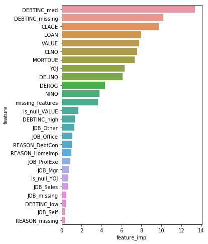

```python
plt.figure(figsize = (5, 8))
sns.barplot(data=feature_importance,x='feature_imp',y='feature')
```

```python
#pd.DataFrame(df_train.corr()['BAD'].sort_values(ascending=False))
correlation_matrix=copy.deepcopy(x_train)
correlation_matrix['BAD']=Y
pd.DataFrame(correlation_matrix.corr()['BAD'].sort_values(ascending=False))
```

|  | BAD |
| --- | --- |
| BAD | 1.000000 |
| DEBTINC_missing | 0.549193 |
| DELINQ | 0.325839 |
| DEROG | 0.287057 |
| is_null_VALUE | 0.243623 |
| missing_features | 0.186349 |
| NINQ | 0.179568 |
| DEBTINC_high | 0.142017 |
| JOB_Other | 0.072664 |
| JOB_Sales | 0.055248 |
| JOB_Self | 0.045829 |
| REASON_HomeImp | 0.041441 |
| JOB_Mgr | 0.015414 |
| CLNO | -0.012366 |
| DEBTINC_low | -0.012802 |
| REASON_missing | -0.015939 |
| REASON_DebtCon | -0.033329 |
| JOB_ProfExe | -0.040437 |
| VALUE | -0.048235 |
| MORTDUE | -0.048963 |
| is_null_YOJ | -0.056222 |
| JOB_missing | -0.061468 |
| LOAN | -0.072913 |
| YOJ | -0.073843 |
| JOB_Office | -0.074137 |
| CLAGE | -0.171396 |
| DEBTINC_med | -0.561890 |

```python
df_analysis=copy.deepcopy(x_test)
df_analysis['BAD']=y_test
df_analysis['pred_prob']=clf.predict_proba(x_test)[:,1]
df_analysis['pred']=clf.predict(x_test)
df_analysis=df_analysis.sort_values(by='pred_prob').reset_index(drop=True)
df_analysis['index']=df_analysis.index
df_analysis['bins']= pd.cut(x=df_analysis['index'],bins=10)
```

```python
df_ana=df_analysis.groupby('bins').agg({'BAD':'count'}).rename({'BAD':'count'},axis=1).reset_index()
```

```python
df_ana['no_default']=np.array(df_analysis.groupby('bins').agg({'BAD':'sum'}))
df_ana['min_prob']=np.array(df_analysis.groupby('bins').agg({'pred_prob':'min'})['pred_prob'])
df_ana['max_prob']=np.array(df_analysis.groupby('bins').agg({'pred_prob':'max'})['pred_prob'])
df_ana['%default']=np.array(df_analysis.groupby('bins').agg({'BAD':'mean'})*100)
```

```python
df_ana['bins']=df_ana.index
df_ana
# prob bins
```

|  | bins | count | no_default | min_prob | max_prob | %default |
| --- | --- | --- | --- | --- | --- | --- |
| 0 | 0 | 96 | 0 | 0.00 | 0.00 | 0.000000 |
| 1 | 1 | 95 | 0 | 0.00 | 0.00 | 0.000000 |
| 2 | 2 | 95 | 0 | 0.00 | 0.01 | 0.000000 |
| 3 | 3 | 96 | 0 | 0.01 | 0.01 | 0.000000 |
| 4 | 4 | 95 | 2 | 0.02 | 0.03 | 2.105263 |
| 5 | 5 | 95 | 1 | 0.03 | 0.06 | 1.052632 |
| 6 | 6 | 96 | 6 | 0.06 | 0.18 | 6.250000 |
| 7 | 7 | 95 | 42 | 0.20 | 0.48 | 44.210526 |
| 8 | 8 | 95 | 70 | 0.49 | 0.73 | 73.684211 |
| 9 | 9 | 96 | 89 | 0.74 | 0.98 | 92.708333 |

```python
df_obs= df_analysis.groupby('bins').mean().reset_index()
df_obs['bins']=df_obs.index
df_obs.head()
```

|  | bins | LOAN | MORTDUE | VALUE | YOJ | DEROG | DELINQ | CLAGE | NINQ | CLNO | ... | DEBTINC_high | DEBTINC_low | DEBTINC_med | DEBTINC_missing | is_null_VALUE | is_null_YOJ | BAD | pred_prob | pred | index |
| --- | --- | --- | --- | --- | --- | --- | --- | --- | --- | --- | --- | --- | --- | --- | --- | --- | --- | --- | --- | --- | --- |
| 0 | 0 | 20020.833333 | 73178.248791 | 100095.916667 | 10.507832 | -0.083333 | -0.010417 | 17.809998 | 0.802083 | 20.766443 | ... | 0.010417 | 0.010417 | 0.979167 | 0.000000 | 0.000000 | 0.197917 | 0.000000 | 0.000000 | 0.0 | 47.5 |
| 1 | 1 | 20426.315789 | 72503.447021 | 104828.989474 | 10.312065 | -0.126316 | -0.105263 | 16.762024 | 0.621053 | 21.327969 | ... | 0.000000 | 0.021053 | 0.978947 | 0.000000 | 0.000000 | 0.157895 | 0.000000 | 0.000000 | 0.0 | 143.0 |
| 2 | 2 | 19318.947368 | 80011.429829 | 111573.428769 | 8.875909 | -0.178947 | -0.073684 | 16.179834 | 0.631579 | 21.079397 | ... | 0.010526 | 0.010526 | 0.978947 | 0.000000 | 0.010526 | 0.084211 | 0.000000 | 0.005158 | 0.0 | 238.0 |
| 3 | 3 | 19272.916667 | 74735.737852 | 96802.781250 | 8.686144 | -0.020833 | 0.031250 | 16.536599 | 0.687500 | 22.201561 | ... | 0.000000 | 0.010417 | 0.989583 | 0.000000 | 0.000000 | 0.145833 | 0.000000 | 0.010000 | 0.0 | 333.5 |
| 4 | 4 | 17612.631579 | 73967.653687 | 100783.663158 | 8.282969 | -0.105263 | 0.084211 | 15.265110 | 0.800000 | 21.886240 | ... | 0.010526 | 0.010526 | 0.968421 | 0.010526 | 0.000000 | 0.052632 | 0.021053 | 0.022421 | 0.0 | 429.0 |

5 rows × 31 columns

```python
cols=feature_importance.loc[0:2,'feature']
```

#### ploting top 3 features(high feature importance) with prob bins

```
feature_importance:  13.390704603878746
```

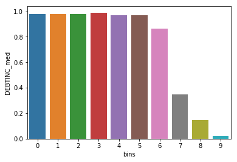

```python
print('feature_importance: ',feature_importance.loc[0,'feature_imp'])
sns.barplot(data=df_obs,y=cols[0],x='bins')
```

```
feature_importance:  10.193750930737282
```

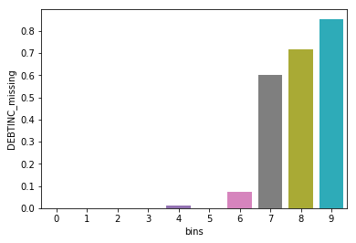

```python
print('feature_importance: ',feature_importance.loc[1,'feature_imp'])
sns.barplot(data=df_obs,y=cols[1],x='bins')
```

```
feature_importance:  9.721074179080667
```

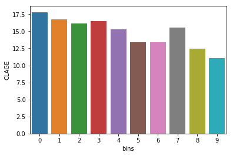

```python
print('feature_importance: ',feature_importance.loc[2,'feature_imp'])
sns.barplot(data=df_obs,y=cols[2],x='bins')
```

### wrong prediction analysis

```python
df_wrong=df_analysis.loc[df_analysis['pred']!=df_analysis['BAD']].reset_index(drop=True)
df_correct=df_analysis.loc[df_analysis['pred']==df_analysis['BAD']].reset_index(drop=True)
```

```python
df_wrong['BAD'].value_counts()
# wrong counts by true labels
```

```
1    58
0    28
Name: BAD, dtype: int64
```

```python
df_correct['BAD'].value_counts()
# correct counts
```

```
0    716
1    152
Name: BAD, dtype: int64
```

```python
df_wrong_obs=df_wrong.groupby('BAD').mean().reset_index()
df_wrong_obs['class']='wrong'
df_correct_obs=df_correct.groupby('BAD').mean().reset_index()
df_correct_obs['class']='correct'
df_obs=pd.concat([df_correct_obs,df_wrong_obs]).reset_index(drop=True)
df_obs
```

|  | BAD | LOAN | MORTDUE | VALUE | YOJ | DEROG | DELINQ | CLAGE | NINQ | CLNO | ... | DEBTINC_high | DEBTINC_low | DEBTINC_med | DEBTINC_missing | is_null_VALUE | is_null_YOJ | pred_prob | pred | index | class |
| --- | --- | --- | --- | --- | --- | --- | --- | --- | --- | --- | --- | --- | --- | --- | --- | --- | --- | --- | --- | --- | --- |
| 0 | 0 | 18547.346369 | 73473.367546 | 101300.144506 | 8.828888 | -0.027933 | 0.115922 | 15.695013 | 0.765363 | 21.408329 | ... | 0.012570 | 0.018156 | 0.893855 | 0.075419 | 0.002793 | 0.107542 | 0.050992 | 0.0 | 360.800279 | correct |
| 1 | 1 | 15193.421053 | 63905.179281 | 87853.359171 | 8.954369 | 0.401316 | 1.059211 | 11.364923 | 1.322368 | 21.142997 | ... | 0.125000 | 0.000000 | 0.092105 | 0.782895 | 0.157895 | 0.065789 | 0.756250 | 1.0 | 868.710526 | correct |
| 2 | 0 | 16560.714286 | 74448.035714 | 90438.145357 | 7.125000 | 0.142857 | 0.464286 | 12.514296 | 1.285714 | 23.321429 | ... | 0.107143 | 0.000000 | 0.000000 | 0.892857 | 0.000000 | 0.000000 | 0.673929 | 1.0 | 835.214286 | wrong |
| 3 | 1 | 16722.413793 | 71384.496270 | 97019.693091 | 8.921194 | 0.034483 | 0.465517 | 14.516538 | 0.603448 | 22.023274 | ... | 0.051724 | 0.017241 | 0.637931 | 0.293103 | 0.051724 | 0.051724 | 0.332586 | 0.0 | 703.758621 | wrong |

4 rows × 31 columns

```python
col=feature_importance.loc[0:2,'feature']
ft_imp=feature_importance.loc[0:3,'feature_imp']
```

```python
def wrong_plot(k):
    print('feature_importance: ',ft_imp[k])
    sns.catplot(data=df_obs,y=col[k],x='class',kind='bar',hue='BAD')
```

#### analyzing the points which are wrongly classified (by top 3 feature by feature imp)

```
feature_importance:  13.390704603878746
```

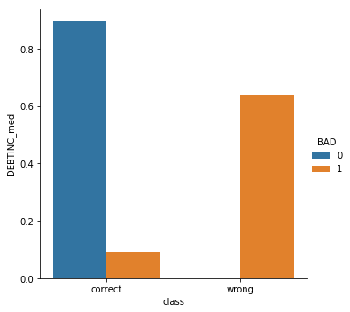

```python
wrong_plot(0)  # average of a feature if correctly/wrongly classified
```

```
feature_importance:  10.193750930737282
```

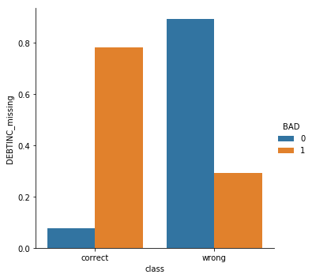

```python
wrong_plot(1)
```

```
feature_importance:  9.721074179080667
```

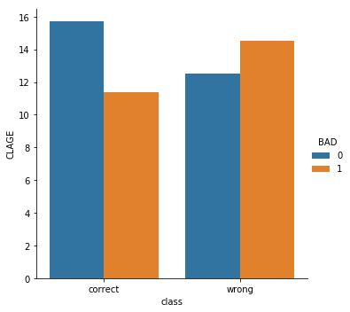

```python
wrong_plot(2)
```

```python
### picking up points which are wrongly classified with high confidence
wrong_pred_as_0=df_wrong.iloc[0:3,:]   ## actually are 1 class but predicted as 0
```

```python
col=[]
for i in feature_importance.loc[0:2,'feature']:
    col.append(i)
col.append('BAD')
col.append('pred')
col.append('pred_prob')
### observing top three features of feature importance
wrong_pred_as_0[col]  #### opposite trend to what  model learned
```

|  | DEBTINC_med | DEBTINC_missing | CLAGE | BAD | pred | pred_prob |
| --- | --- | --- | --- | --- | --- | --- |
| 0 | 1.0 | 0.0 | 16.315072 | 1 | 0 | 0.02 |
| 1 | 1.0 | 0.0 | 25.047876 | 1 | 0 | 0.03 |
| 2 | 1.0 | 0.0 | 8.102594 | 1 | 0 | 0.04 |

```python
wrong_pred_as_1=df_wrong.iloc[-4:-1,:]  ## actually are 0 class but predicted as 1
```

```python
### observing top three features of feature importance
wrong_pred_as_1[col]  #### opposite trend to what  model learned in Debtinc
```

|  | DEBTINC_med | DEBTINC_missing | CLAGE | BAD | pred | pred_prob |
| --- | --- | --- | --- | --- | --- | --- |
| 82 | 0.0 | 1.0 | 7.061111 | 0 | 1 | 0.84 |
| 83 | 0.0 | 1.0 | 17.169444 | 0 | 1 | 0.84 |
| 84 | 0.0 | 1.0 | 9.805556 | 0 | 1 | 0.86 |